# Hybrid & Technical Strategy Backtest, Optimizations, and Comparision.

[figure not shown]

```r
# WinRate
winrate_long <- performance_summary_df %>%
  select(Symbol, Strategy, WinRate_Original, WinRate_Optimized) %>%
  pivot_longer(cols = c(WinRate_Original, WinRate_Optimized),
               names_to = "Version", values_to = "WinRate")

winrate_long$Version <- gsub("WinRate_", "", winrate_long$Version)

# Visualization
ggplot(winrate_long, aes(x = Symbol, y = WinRate, fill = Version)) +
  geom_col(position = "dodge") +
  facet_wrap(~ Strategy) +
  labs(title = " WinRate: Original vs Optimized",
       y = "Win Rate", x = "Symbol") +
  theme_minimal()
```

got way better, for both sharp ratio is way better than before, which means its very profitable with less volatility, and also win rate is higher too, which means its winning more times than original.

```r
library(dplyr)
library(ggplot2)
library(xts)
library(PerformanceAnalytics)

symbols <- c("NVDA", "SOXL", "XOM", "CLS.TO")

compare_results <- data.frame()
cumret_list <- list()

for (sym in symbols) {
  cat("\n", sym, ": Comparing Technical vs Hybrid...\n")

  # Best Technical Result
  tech_row <- global_results[[sym]] |> filter(Score == max(Score))
  w1_t <- tech_row$w1
  w2_t <- tech_row$w2
  threshold_t <- tech_row$threshold

  f_tech <- p_ma_3_12_sync
  f_tech[symbols] <- w1_t * p_ma_3_12_sync[symbols] + w2_t * p_risk_sync[symbols]
  names(f_tech)[-1] <- paste0("f_tech_", symbols)

  f_col_t <- paste0("f_tech_", sym)
  ret_col <- paste0("logret_", sym)
  df_t <- merge(f_tech[, c("Date", f_col_t)],
                logret_df[, c("Date", ret_col)], by = "Date") |> arrange(Date)
  df_t$signal <- ifelse(df_t[[f_col_t]] > threshold_t, 1,
                        ifelse(df_t[[f_col_t]] < (1 - threshold_t), -1, 0))
  df_t$position <- dplyr::lag(df_t$signal, 1, default = 0)
  df_t$strat_ret <- df_t$position * df_t[[ret_col]]
  df_t$cum_ret <- cumsum(ifelse(is.na(df_t$strat_ret), 0, df_t$strat_ret))
  sharpe_t <- mean(df_t$strat_ret, na.rm=TRUE) / sd(df_t$strat_ret, na.rm=TRUE)
  winrate_t <- sum(df_t$strat_ret > 0, na.rm=TRUE) / sum(!is.na(df_t$strat_ret))

  cumret_list[[paste0(sym, "_Technical")]] <- data.frame(
    Date = df_t$Date, cum_ret = df_t$cum_ret, Label = paste0(sym, " - Technical"))

  # Best Hybrid result
  hyb_row <- global_results_hyb[[sym]] |> filter(Score == max(Score))
  w1_h <- hyb_row$w1
  w2_h <- hyb_row$w2
  alpha <- hyb_row$alpha
  threshold_h <- hyb_row$threshold

  f_tech_h <- p_ma_3_12_sync
  f_tech_h[symbols] <- w1_h * p_ma_3_12_sync[symbols] + w2_h * p_risk_sync[symbols]
  names(f_tech_h)[-1] <- paste0("f_tech_", symbols)

  f_hyb <- f_tech_h[, "Date", drop=FALSE]
  for (s in symbols) {
    f_hyb[[paste0("f_hyb_", s)]] <- alpha * f_tech_h[[paste0("f_tech_", s)]] +
                                    (1 - alpha) * p_econ_sync[[s]]
  }

  f_col_h <- paste0("f_hyb_", sym)
  df_h <- merge(f_hyb[, c("Date", f_col_h)],
                logret_df[, c("Date", ret_col)], by = "Date") |> arrange(Date)
  df_h$signal <- ifelse(df_h[[f_col_h]] > threshold_h, 1,
                        ifelse(df_h[[f_col_h]] < (1 - threshold_h), -1, 0))
  df_h$position <- dplyr::lag(df_h$signal, 1, default = 0)
  df_h$strat_ret <- df_h$position * df_h[[ret_col]]
  df_h$cum_ret <- cumsum(ifelse(is.na(df_h$strat_ret), 0, df_h$strat_ret))
  sharpe_h <- mean(df_h$strat_ret, na.rm=TRUE) / sd(df_h$strat_ret, na.rm=TRUE)
  winrate_h <- sum(df_h$strat_ret > 0, na.rm=TRUE) / sum(!is.na(df_h$strat_ret))

  cumret_list[[paste0(sym, "_Hybrid")]] <- data.frame(
    Date = df_h$Date, cum_ret = df_h$cum_ret, Label = paste0(sym, " - Hybrid"))

  # Store performance comparison
  compare_results <- rbind(compare_results, data.frame(
    Symbol = sym,
    Sharpe_Technical = sharpe_t,
    WinRate_Technical = winrate_t,
    Sharpe_Hybrid = sharpe_h,
    WinRate_Hybrid = winrate_h
  ))
}
```

```
##
##  NVDA : Comparing Technical vs Hybrid...
##
##  SOXL : Comparing Technical vs Hybrid...
##
##  XOM : Comparing Technical vs Hybrid...
##
##  CLS.TO : Comparing Technical vs Hybrid...
```

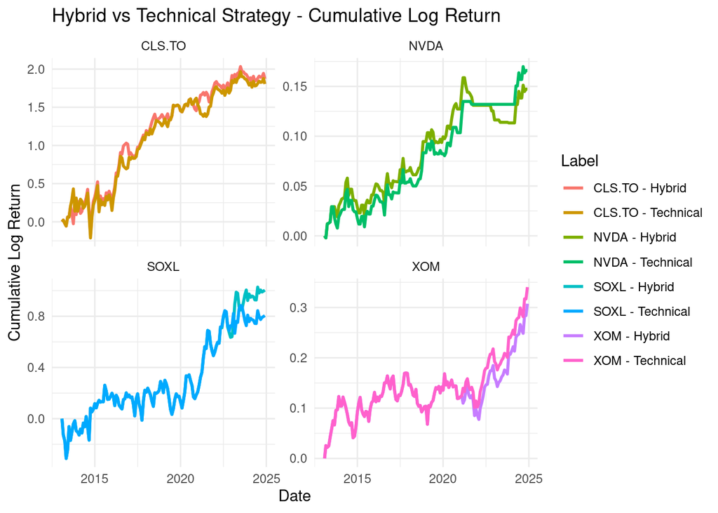

```r
#  Compare Cumulative Return Graphs
cumret_df <- bind_rows(cumret_list)
ggplot(cumret_df, aes(x = Date, y = cum_ret, color = Label)) +
  geom_line(linewidth = 1) +
  facet_wrap(~ gsub(" - .*", "", Label), scales = "free_y") +
  labs(title = "Hybrid vs Technical Strategy - Cumulative Log Return",
       y = "Cumulative Log Return") +
  theme_minimal()
```

```r
#  Performance comparison table
compare_results
```

```
##   Symbol Sharpe_Technical WinRate_Technical Sharpe_Hybrid WinRate_Hybrid
## 1   NVDA        0.1861319         0.3028169     0.1612738      0.3309859
## 2   SOXL        0.0853663         0.4788732     0.1066271      0.4929577
## 3    XOM        0.1625968         0.5985915     0.1464631      0.5915493
## 4 CLS.TO        0.1442340         0.5704225     0.1496646      0.5915493
```

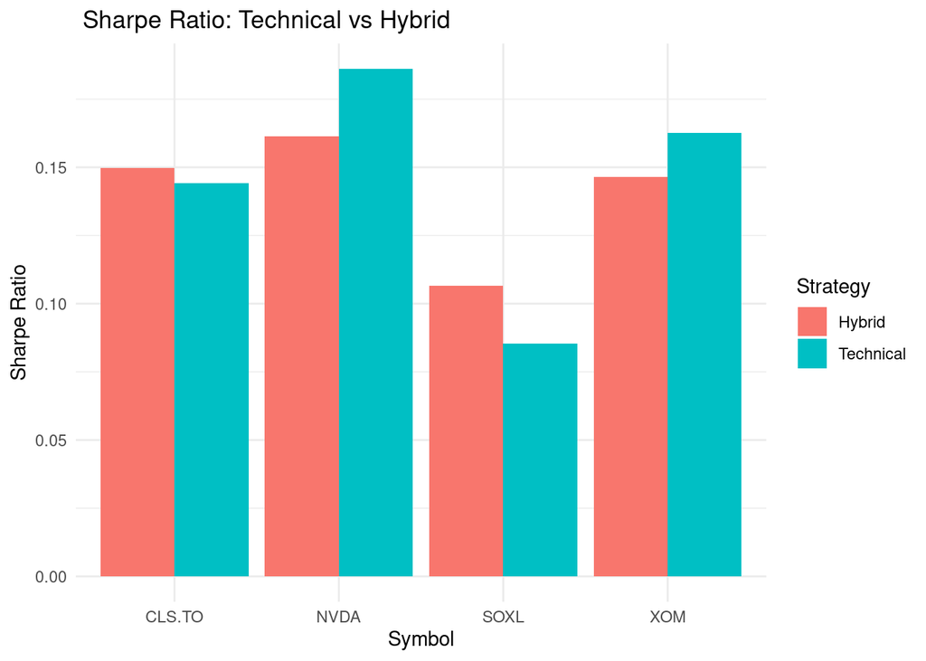

```r
performance_comparison_df <- data.frame(
  Symbol = rep(c("NVDA", "SOXL", "XOM", "CLS.TO"), each = 2),
  Strategy = rep(c("Technical", "Hybrid"), times = 4),
  Sharpe = c(0.1861, 0.1613, 0.0854, 0.1066, 0.1626, 0.1465, 0.1442, 0.1497),
  WinRate = c(0.3028, 0.3310, 0.4789, 0.4930, 0.5986, 0.5915, 0.5704, 0.5915)
)
library(ggplot2)

ggplot(performance_comparison_df, aes(x = Symbol, y = Sharpe, fill = Strategy)) +
  geom_col(position = "dodge") +
  labs(title = " Sharpe Ratio: Technical vs Hybrid",
       y = "Sharpe Ratio", x = "Symbol") +
  theme_minimal()
```

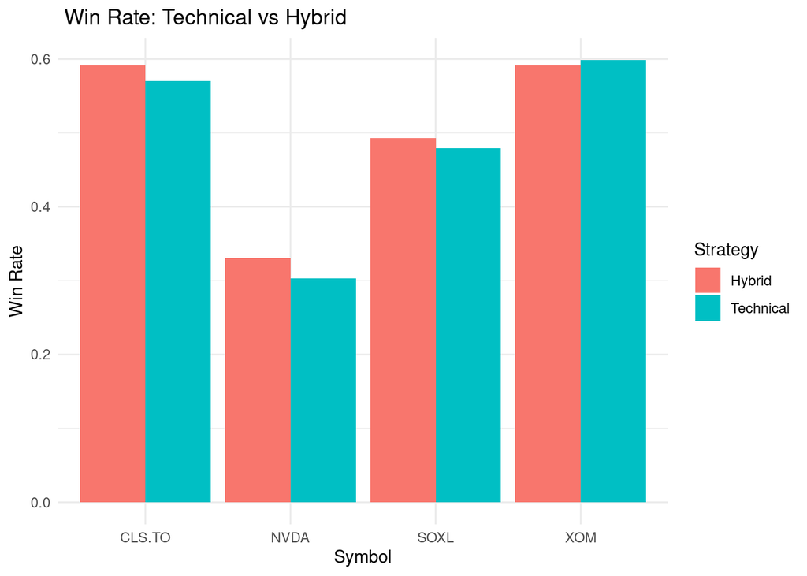

```r
ggplot(performance_comparison_df, aes(x = Symbol, y = WinRate, fill = Strategy)) +
  geom_col(position = "dodge") +
  labs(title = " Win Rate: Technical vs Hybrid",
       y = "Win Rate", x = "Symbol") +
  theme_minimal()
```

hybrid & technical comparision is more interesting, since boths are very similar,

Technical strategies show higher Sharpe Ratio on average. → In other words, they are slightly more efficient in terms of risk-to-return ratio.

Strategic Insight: For investors who want to avoid short-term or loss periods, Hybrid strategies with higher WinRate may be more stable.

For investors who value long-term returns and efficiency, Technical strategies with higher Sharpe may be more suitable.

Depending on the stock, there are cases where Hybrids are slightly ahead in all indicators, such as CLS.TO or SOXL.